# Weather analysis in Greece

## First Assignment for Practical Data Science Course (Data Science - AUEB 2021). Analysis and Visualisation of weather conditions in Greece using data from the National Oceanic and Atmospheric Administration's National Centers for Environmental Information and the Hellenic Data Service

Posted by Christodoulos Santorinaios on July 24, 2022 · 368 mins read

# Exploring the Weather in Athens

In this assignment you will explore the weather in Athens over a period of more than 50 years.

> Panos Louridas, Associate Professor  
> Department of Management Science and Technology  
> Athens University of Economics and Business  
> louridas@aueb.gr

## Questions

### Q1: Obtain the Data

You will work with data covering the period from 1955 to 2020. The data will be obtained from two sources:

- Data downloaded from the National Oceanic and Atmospheric Administration's National Centers for Environmental Information (https://www.ncdc.noaa.gov/cdo-web/) and in particular https://www.ncdc.noaa.gov/cdo-web/search.
- As we are focusing on Athens, you will use the data from the Hellinikon weather station and you will concentrate on the average daily temperature and precipitation.
- Explore the completeness of the data. What data are missing?
- To fill in any missing data you will use an alternative dataset available from https://data.hellenicdataservice.gr/dataset/66e1c19a-7b0e-456f-b465-b301a1130e3f; this dataset covers only the period from 2010-2019.

To download the data from the National Oceanic and Atmospheric Administration's National Centers for Environmental Information we follow the steps below.

1. We start by navigating to the https://www.ncdc.noaa.gov/cdo-web/search and inputting the required fields for our search as seen below. Here we fill the fields with values:
   - Dataset: Daily Summaries
   - Date Range: 1955-01-01 to 2019-12-31
   - Search for: Stations
   - Search Term: Hellinikon

[figure not shown]

1. In the page that loads, we select the Hellinikon station in the upper left side.

[figure not shown]

2. Next we add the dataset to the cart

[figure not shown]

3. In the cart options we select csv format and the date range for which we want to collect the data

[figure not shown]

4. At the custom options we select the fields we want to have in our dataset and the units of our data (metric). For our case we should only select data about temperature and precipitation, but I select all the fields just to be safe

[figure not shown]

5. In the page that loads we can confirm our selections and place our order by inputting a valid email address. It's safe to input a personal or business email address here as NOAA will use the email address for the sole purpose of communicating the order status to us.

[figure not shown]

6. After submitting the request we are informed that the order is complete and get various information about the dataset. After a couple of minutes we receive a link to our email with the dataset or we can check order status and the download link will be there.

[figure not shown]

We have two options here. We can use the download link to connect to the csv online (although it expires after 30 days) or we can download and work with dataset locally. I chose the second option.

Now that we have the data, let's import the libraries we are going to use in our analysis.

```python
#import required libraries
%matplotlib inline
import pandas as pd
import matplotlib.pyplot as plt
import matplotlib
import seaborn as sns
matplotlib.rcParams['figure.dpi'] = 300
```

We read the data and it's important here to use the **parse_dates** argument to get the dates as datetime64 objects.

```python
# read csv as dataframe parsing dates

df = pd.read_csv('noaa.csv', parse_dates=['DATE'])
```

Let's have a look on our data, descriptive statistics, missing values, etc. to get a first understanding of what's going on.

```python
df.shape
```

```
(22885, 16)
```

```python
df.sample(10)
```

|  | STATION | NAME | LATITUDE | LONGITUDE | ELEVATION | DATE | PRCP | PRCP_ATTRIBUTES | SNWD | SNWD_ATTRIBUTES | TAVG | TAVG_ATTRIBUTES | TMAX | TMAX_ATTRIBUTES | TMIN | TMIN_ATTRIBUTES |
| --- | --- | --- | --- | --- | --- | --- | --- | --- | --- | --- | --- | --- | --- | --- | --- | --- |
| 8359 | GR000016716 | HELLINIKON, GR | 37.9 | 23.75 | 10.0 | 1977-11-20 | 15.9 | ,,E | NaN | NaN | 15.9 | H,,S | 18.6 | ,,E | 12.1 | ,,E |
| 2476 | GR000016716 | HELLINIKON, GR | 37.9 | 23.75 | 10.0 | 1961-10-12 | 0.0 | ,,E | NaN | NaN | 16.1 | H,,S | 18.6 | ,,E | 14.3 | ,,E |
| 17224 | GR000016716 | HELLINIKON, GR | 37.9 | 23.75 | 10.0 | 2002-02-27 | 0.0 | ,,E | NaN | NaN | 12.9 | H,,S | 17.0 | ,,E | 9.2 | ,,E |
| 8178 | GR000016716 | HELLINIKON, GR | 37.9 | 23.75 | 10.0 | 1977-05-23 | 0.0 | ,,E | NaN | NaN | 23.9 | H,,S | 27.6 | ,,E | 19.8 | ,,E |
| 3632 | GR000016716 | HELLINIKON, GR | 37.9 | 23.75 | 10.0 | 1964-12-11 | 0.0 | ,,E | NaN | NaN | 11.8 | H,,S | 12.0 | ,,E | 10.6 | ,,E |
| 9457 | GR000016716 | HELLINIKON, GR | 37.9 | 23.75 | 10.0 | 1980-11-22 | 0.0 | ,,E | NaN | NaN | 10.7 | H,,S | 16.0 | ,,E | 5.4 | ,,E |
| 21512 | GR000016716 | HELLINIKON, GR | 37.9 | 23.75 | 10.0 | 2016-03-05 | 0.8 | ,,S | NaN | NaN | 13.3 | H,,S | 16.8 | ,,S | 8.6 | ,,S |
| 3238 | GR000016716 | HELLINIKON, GR | 37.9 | 23.75 | 10.0 | 1963-11-13 | 0.0 | ,,E | NaN | NaN | 19.9 | H,,S | 23.6 | ,,E | 16.2 | ,,E |
| 14962 | GR000016716 | HELLINIKON, GR | 37.9 | 23.75 | 10.0 | 1995-12-19 | 4.0 | ,,E | NaN | NaN | 13.6 | H,,S | 15.6 | ,,E | 9.2 | ,,E |
| 3785 | GR000016716 | HELLINIKON, GR | 37.9 | 23.75 | 10.0 | 1965-05-13 | 0.1 | ,,E | NaN | NaN | 15.4 | H,,S | 19.2 | ,,E | 13.0 | ,,E |

```python
df.dtypes
```

```
STATION                    object
NAME                       object
LATITUDE                  float64
LONGITUDE                 float64
ELEVATION                 float64
DATE               datetime64[ns]
PRCP                      float64
PRCP_ATTRIBUTES            object
SNWD                      float64
SNWD_ATTRIBUTES            object
TAVG                      float64
TAVG_ATTRIBUTES            object
TMAX                      float64
TMAX_ATTRIBUTES            object
TMIN                      float64
TMIN_ATTRIBUTES            object
dtype: object
```

```python
df.isna().sum()
```

```
STATION                0
NAME                   0
LATITUDE               0
LONGITUDE              0
ELEVATION              0
DATE                   0
PRCP                 450
PRCP_ATTRIBUTES      450
SNWD               22856
SNWD_ATTRIBUTES    22856
TAVG                2311
TAVG_ATTRIBUTES     2311
TMAX                 903
TMAX_ATTRIBUTES      903
TMIN                 787
TMIN_ATTRIBUTES      787
dtype: int64
```

```python
df.describe()
```

|  | LATITUDE | LONGITUDE | ELEVATION | PRCP | SNWD | TAVG | TMAX | TMIN |
| --- | --- | --- | --- | --- | --- | --- | --- | --- |
| count | 2.288500e+04 | 22885.00 | 22885.0 | 22435.000000 | 29.000000 | 20574.000000 | 21982.000000 | 22098.000000 |
| mean | 3.790000e+01 | 23.75 | 10.0 | 1.017174 | 157.379310 | 18.255366 | 22.325457 | 14.456535 |
| std | 7.105583e-15 | 0.00 | 0.0 | 4.658466 | 359.709547 | 6.927408 | 7.389128 | 6.464360 |
| min | 3.790000e+01 | 23.75 | 10.0 | 0.000000 | 10.000000 | -2.000000 | 1.000000 | -4.200000 |
| 25% | 3.790000e+01 | 23.75 | 10.0 | 0.000000 | 10.000000 | 12.700000 | 16.500000 | 9.400000 |
| 50% | 3.790000e+01 | 23.75 | 10.0 | 0.000000 | 20.000000 | 17.700000 | 21.800000 | 14.200000 |
| 75% | 3.790000e+01 | 23.75 | 10.0 | 0.000000 | 41.000000 | 24.300000 | 28.700000 | 20.000000 |
| max | 3.790000e+01 | 23.75 | 10.0 | 142.000000 | 1240.000000 | 34.800000 | 42.000000 | 30.400000 |

Some first remarks about our data:

- The types of the columns are in the format that we are ok to work with
- There are 450 missing values in precipitation and 2311 in TAVG. These are values we should handle as they are needed for our analysis
- There missing values in TMAX and TMIN as well. We will try ti handle them as well because they might be useful to address the missing average temperature values
- Almost all the values about snowfall are missing but it's something that doesn't concern us because we won't using them in our analysis

As a matter of fact let's go on and create a new dataframe with the columns that are going to be used later on. We don't need any of the station information of course. This dataframe will be a copy of the columns we need from the first one.

```python
df_TEMP_PRCP = df[['DATE', 'TAVG', 'TMIN', 'TMAX', 'PRCP']].copy()
```

```python
df_TEMP_PRCP.sample(10)
```

|  | DATE | TAVG | TMIN | TMAX | PRCP |
| --- | --- | --- | --- | --- | --- |
| 6100 | 1971-09-14 | NaN | 20.3 | 28.8 | 0.0 |
| 20089 | 2010-01-04 | 8.9 | 5.8 | 11.0 | 0.0 |
| 16610 | 2000-06-23 | 26.3 | 19.0 | 31.8 | 0.0 |
| 9575 | 1981-03-20 | 13.4 | 11.0 | 18.4 | 0.0 |
| 14384 | 1994-05-20 | 21.2 | 18.0 | 26.0 | 0.0 |
| 15798 | 1998-04-03 | 14.3 | 10.0 | 20.0 | 0.0 |
| 18153 | 2004-09-13 | 21.1 | 13.0 | 27.2 | 0.0 |
| 10646 | 1984-02-24 | 12.0 | 8.4 | 16.0 | 0.0 |
| 18741 | 2006-04-26 | 17.3 | 12.4 | 22.2 | 0.0 |
| 16221 | 1999-05-31 | 23.2 | 18.6 | 28.8 | 0.0 |

```python
df_TEMP_PRCP.isna().sum()
```

```
DATE       0
TAVG    2311
TMIN     787
TMAX     903
PRCP     450
dtype: int64
```

We will now try to fill the missing values on our dataset to the best of our ability. For this purpose, let's download another dataset that will help us with information about 2010-2019. This is the dataset from the Hellenic Data Service found [here](https://data.hellenicdataservice.gr/dataset/66e1c19a-7b0e-456f-b465-b301a1130e3f). We are interested in **athens.csv** as we want to use it to fill data of Hellinikon Station located in Athens.

```python
# load athens.csv to dataframe, header=None because with it it reads the data in the first row as headers

df_hds = pd.read_csv('https://data.hellenicdataservice.gr/dataset/d3b0d446-aaba-49a8-acce-e7c6f6f5d3b5/resource/a7c024b3-8606-4f08-93e2-2042f5bd6748/download/athens.csv', header=None, parse_dates=[0])
```

```python
df_hds.shape
```

```
(3652, 14)
```

```python
df_hds.sample(10)
```

|  | 0 | 1 | 2 | 3 | 4 | 5 | 6 | 7 | 8 | 9 | 10 | 11 | 12 | 13 |
| --- | --- | --- | --- | --- | --- | --- | --- | --- | --- | --- | --- | --- | --- | --- |
| 2158 | 2015-11-29 | 14.9 | 15.0 | 14.8 | 68.3 | 79 | 55 | 1018.9 | 1021.6 | 1016.7 | 0.0 | 1.4 | SW | 5.8 |
| 1424 | 2013-11-25 | 15.0 | 15.1 | 14.9 | 74.2 | 90 | 53 | 1007.8 | 1008.7 | 1007.3 | 0.2 | 0.7 | N | 3.4 |
| 1671 | 2014-07-30 | 29.6 | 29.7 | 29.5 | 60.6 | 71 | 47 | 1010.2 | 1011.1 | 1009.0 | 0.0 | 2.6 | SW | 8.1 |
| 1737 | 2014-10-04 | 19.0 | 19.0 | 18.9 | 58.4 | 66 | 52 | 1019.7 | 1020.5 | 1018.5 | 0.0 | 9.0 | NNE | 18.7 |
| 936 | 2012-07-25 | 30.1 | 30.3 | 30.0 | 56.1 | 71 | 42 | 1009.5 | 1010.9 | 1008.2 | 0.0 | 3.2 | SSW | 9.7 |
| 182 | 2010-07-02 | 28.0 | 28.2 | 27.9 | 53.7 | 67 | 39 | 1012.3 | 1013.1 | 1011.1 | 0.0 | 3.0 | NNW | 8.9 |
| 1377 | 2013-10-09 | 19.7 | 19.8 | 19.6 | 60.7 | 78 | 35 | 1023.4 | 1025.5 | 1021.7 | 0.0 | 1.8 | SSW | 6.3 |
| 3007 | 2018-03-27 | 15.6 | 15.7 | 15.5 | 62.1 | 78 | 49 | 1012.4 | 1013.7 | 1011.4 | 0.0 | 2.3 | WSW | 7.7 |
| 3508 | 2019-08-10 | 31.7 | 31.8 | 31.6 | 37.4 | 46 | 31 | 1010.8 | 1011.7 | 1009.5 | 0.0 | 11.3 | NNE | 25.6 |
| 849 | 2012-04-29 | 22.2 | 22.3 | 22.0 | 47.6 | 73 | 31 | 1015.3 | 1016.5 | 1013.4 | 0.0 | 3.1 | SW | 9.1 |

We immediately notice that the column headers don't have labels. So, we need to find some documentation about this. Fortunately, [here](https://data.hellenicdataservice.gr/dataset/66e1c19a-7b0e-456f-b465-b301a1130e3f/resource/a7c024b3-8606-4f08-93e2-2042f5bd6748) the dataset is described.

> Each line consists of 14 columns. First is the date of the parameters (YYYY-MM-DD). Next are the mean, maximum and minimum temperature (°C). After that and in the same order we have 6 columns for relative humidity and atmospheric pressure (%, hPa). The tenth column is the daily rainfall (mm). In the last 3 columns we can see mean wind speed, dominant wind direction as well as wind gust (km/h).

Let's now rename the columns.

```python
df_hds.rename(columns={0: 'DATE', 1: 'TAVG', 2: 'TMAX', 3: 'TMIN', 4: 'HUMAVG', 5: 'HUMMAX', 6: 'HUMMIN', 7: 'ATMAVG',
                       8: 'ATMMAX', 9: 'ATMMIN', 10: 'RAIN', 11: 'WINDAVG', 12: 'WINDDIR', 13: 'WINDGUST'}, inplace=True)
```

```python
df_hds.head()
```

|  | DATE | TAVG | TMAX | TMIN | HUMAVG | HUMMAX | HUMMIN | ATMAVG | ATMMAX | ATMMIN | RAIN | WINDAVG | WINDDIR | WINDGUST |
| --- | --- | --- | --- | --- | --- | --- | --- | --- | --- | --- | --- | --- | --- | --- |
| 0 | 2010-01-01 | 17.9 | 18.1 | 17.8 | 61.4 | 91 | 33 | 1003.6 | 1006.3 | 1002.0 | 0.2 | 4.0 | WSW | 12.7 |
| 1 | 2010-01-02 | 15.6 | 15.7 | 15.5 | 57.4 | 70 | 45 | 1005.2 | 1008.7 | 1001.5 | 0.0 | 6.8 | WSW | 20.7 |
| 2 | 2010-01-03 | 13.5 | 13.6 | 13.4 | 56.0 | 76 | 39 | 1011.7 | 1016.7 | 1008.6 | 0.0 | 5.0 | WSW | 15.4 |
| 3 | 2010-01-04 | 9.5 | 9.6 | 9.5 | 50.7 | 60 | 38 | 1021.3 | 1023.1 | 1016.8 | 0.0 | 4.3 | NNE | 11.0 |
| 4 | 2010-01-05 | 13.4 | 13.5 | 13.4 | 70.5 | 82 | 54 | 1018.7 | 1022.1 | 1015.5 | 0.0 | 7.9 | S | 19.8 |

Let's keep the columns we are interested in by taking a copy of this dataframe. Note that precipitation is the rain variable in the second dataset so let's change the column name.

```python
df_hds.rename(columns={'RAIN': 'PRCP'}, inplace=True)
```

```python
df_hds_TEMP_PRCP = df_hds[['DATE', 'TAVG', 'TMAX', 'TMIN', 'PRCP']].copy()
```

```python
df_hds_TEMP_PRCP.isna().sum()
```

```
DATE    0
TAVG    0
TMAX    0
TMIN    0
PRCP    0
dtype: int64
```

There are no missing values in the second dataset. Now, let's look what we can cover from our original dataset.

Since we are going to combine data from different dataframes and we are working with dates, a good idea would be to turn the DATES column to index column in both dataframes.

```python
df_TEMP_PRCP.set_index(['DATE'], inplace=True)
```

```python
df_hds_TEMP_PRCP.set_index(['DATE'], inplace=True)
```

While trying to find the average I got this error:

[figure not shown]

I didn't expect to get an error here and I started searching for the issue as I thought that everything I had was numbers. Running df_TEMP_PRCP.dtypes got me:

[figure not shown]

I had seen that I had only float64 objects in df_TEMP_PRCP at the start so the problem should have been in df_hds_TEMP_PRCP. Indeed, there the temperatures were objects and not float64 and when I tried to convert them got this error message:

[figure not shown]

Ok, that was unexpected. There were some dashes in the data in some columns and I didn't find them as they are not considered na. I located these rows.

[figure not shown]

Then checked in the first dataset, if I have any values for them.

[figure not shown]

I had in the two of the three rows, so here I choose to drop them and move on with my analysis.

```python
df_hds_TEMP_PRCP[(df_hds_TEMP_PRCP.TMIN == '---') | (df_hds_TEMP_PRCP.TMAX == '---') | (df_hds_TEMP_PRCP.TAVG == '---')].index
```

```
DatetimeIndex(['2011-05-30', '2013-05-20', '2015-07-06'], dtype='datetime64[ns]', name='DATE', freq=None)
```

```python
convert_dict = {'TMIN': float,
                'TMAX': float,
                'TAVG': float
               }
```

```python
df_hds_TEMP_PRCP.drop(labels=[pd.Timestamp('2011-05-30 00:00:00'), pd.Timestamp('2013-05-20 00:00:00'), pd.Timestamp('2015-07-06 00:00:00')], inplace=True)
```

```python
df_hds_TEMP_PRCP = df_hds_TEMP_PRCP.astype(convert_dict)
```

```python
df_hds_TEMP_PRCP.dtypes
```

```
TAVG    float64
TMAX    float64
TMIN    float64
PRCP    float64
dtype: object
```

We now fill the na values of the df_TEMP_PRCP dataframe with the values from the df_hds_TEMP_PRCP dataframe.

```python
df_TEMP_PRCP.fillna(df_hds_TEMP_PRCP, inplace=True)
```

```python
df_TEMP_PRCP[(df_TEMP_PRCP.index.year>=2010) & (df_TEMP_PRCP.index.year<2020)]
```

| DATE | TAVG | TMIN | TMAX | PRCP |
| --- | --- | --- | --- | --- |
| 2010-01-01 | 18.0 | 17.8 | 21.8 | 0.2 |
| 2010-01-02 | 16.0 | 13.8 | 17.8 | 0.0 |
| 2010-01-03 | 13.5 | 10.8 | 15.6 | 0.0 |
| 2010-01-04 | 8.9 | 5.8 | 11.0 | 0.0 |
| 2010-01-05 | 13.1 | 8.6 | 16.0 | 0.0 |
| ... | ... | ... | ... | ... |
| 2019-12-27 | 9.8 | 6.2 | 13.4 | 0.0 |
| 2019-12-28 | 8.6 | 8.2 | 10.8 | 0.0 |
| 2019-12-29 | 5.9 | 3.8 | 8.0 | 17.5 |
| 2019-12-30 | 4.2 | 3.9 | 7.7 | 4.6 |
| 2019-12-31 | 5.9 | 2.8 | 6.5 | 37.6 |

2799 rows × 4 columns

Perfect, now the data in the columns of df_TEMP_PRCP are filled and we have everything we need... Well, that is almost the case. Notice though that there 2799 rows in the dataframe instead of 3649 that should have been there (noticed this in the number of rows of the df_hds dataframe). So, let's go on and fill these rows as well. To do this, we find the difference in indexes between the two dataframes and then we concatenate them.

```python
index_difference = df_hds_TEMP_PRCP.index.difference(df_TEMP_PRCP.index)
```

```python
len(index_difference)
```

```
852
```

```python
df_TEMP_PRCP = pd.concat([df_TEMP_PRCP, df_hds_TEMP_PRCP.loc[index_difference]], axis=0).sort_index()
```

```python
df_TEMP_PRCP[(df_TEMP_PRCP.index.year>=2010) & (df_TEMP_PRCP.index.year<2020)].shape
```

```
(3651, 4)
```

```python
df_TEMP_PRCP[(df_TEMP_PRCP.index.year>=2010) & (df_TEMP_PRCP.index.year<2020)].isna().sum()
```

```
TAVG    0
TMIN    0
TMAX    0
PRCP    0
dtype: int64
```

For now, it seems ok and we don't need the second dataframe anymore.

As a sidenote, I noticed that there were discrepancies in the values of the second dataset to the values of the first. For our analysis, I choose to keep the values of the first set and only fill missing values from the second. I could take their average or keep the values from the second dataset, but I choose not to as the purpose of our initial research was only to fill missing values.

Let's check the dataframe now.

```python
df_TEMP_PRCP.isna().sum()
```

```
TAVG    2311
TMIN     338
TMAX      83
PRCP     348
dtype: int64
```

There are still missing values. We will try to cover the TAVG by taking the average of TMIN and TMAX. This, of course, is not totally correct as in a day we could have values near TMIN or TMAX for most of the day so the average isn't accurate but just to have an estimation and better fill our data.

```python
df_TEMP_PRCP.TAVG = df_TEMP_PRCP.TAVG.fillna((df_TEMP_PRCP.TMIN + df_TEMP_PRCP.TMAX)/2)
```

```python
df_TEMP_PRCP.dtypes
```

```
TAVG    float64
TMIN    float64
TMAX    float64
PRCP    float64
dtype: object
```

```python
df_TEMP_PRCP.isna().sum()
```

```
TAVG      1
TMIN    338
TMAX     83
PRCP    348
dtype: int64
```

```python
df_TEMP_PRCP[df_TEMP_PRCP.TAVG.isna()]
```

| DATE | TAVG | TMIN | TMAX | PRCP |
| --- | --- | --- | --- | --- |
| 1957-03-09 | NaN | NaN | 16.9 | 0.3 |

### Q2: Deviation of Summer Temperatures

The Hellenic National Meteorological Service has published a report on extreme weather events for 2020. The report is available at http://www.hnms.gr/emy/en/pdf/2020_GRsignificantEVENT_en.pdf. In page 7 of the report there is a graph showing the mean summer temperature deviation from a baseline of 1971-2000.

You will create your own version of the graph, using a baseline of 1974-1999. Your graph should look like the one below. The line that runs through the graph is the 10 years rolling avarege of the deviation from the mean. What is your intepretation of the figure?

[figure not shown]

We need to calculate the baseline mean temperature for the summers of 1974-1999. So, let's get the mean summer temperatures of these years.

```python
baseline_mean_temp = df_TEMP_PRCP[(df_TEMP_PRCP.index.year>=1974) & (df_TEMP_PRCP.index.year<=1999) & (df_TEMP_PRCP.index.month>=6) & (df_TEMP_PRCP.index.month<=8)].TAVG.mean()
```

```python
df_TEMP_PRCP_summer = df_TEMP_PRCP[(df_TEMP_PRCP.index.month>=6) & (df_TEMP_PRCP.index.month<=8)]
```

```python
df_summer_means = df_TEMP_PRCP_summer['TAVG'].groupby(df_TEMP_PRCP_summer.index.year).mean()
```

```python
df_summer_means_dif = df_summer_means - baseline_mean_temp
```

```python
df_summer_means_dif
```

```
DATE
1955   -0.279640
1956    0.912751
1957    1.141012
1958    0.850794
1959    0.170360
          ...
2015    1.092099
2016    1.923620
2017    1.857316
2018    1.206229
2019    1.804055
Name: TAVG, Length: 65, dtype: float64
```

```python
df_rolling = df_summer_means_dif.rolling(window=10, min_periods=1).mean()
```

```python
from IPython.core.display import HTML
HTML("""
<style>
.output_png {
    display: table-cell;
    text-align: center;
    vertical-align: middle;
}
</style>
""")
```

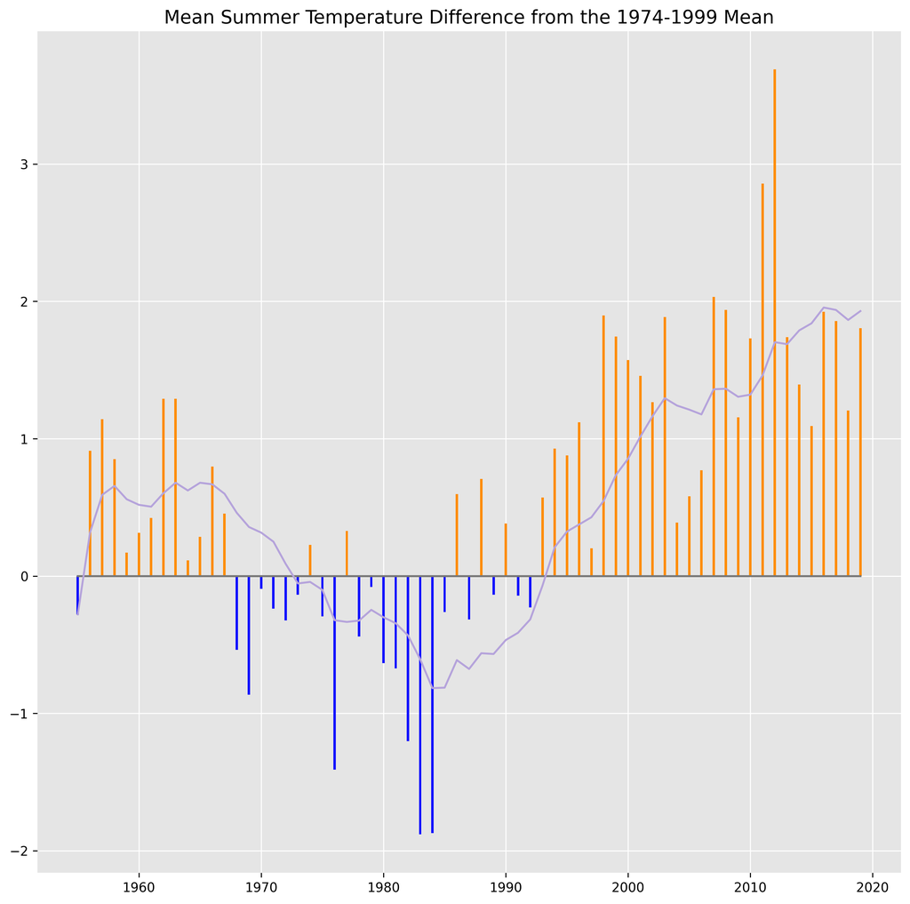

```python
fig, ax = plt.subplots(nrows=1, ncols=1, figsize=(12,12))
ax.set_axisbelow(True)
plt.rcParams.update({'axes.titlesize': 'x-large'})
ax.set_title('Mean Summer Temperature Difference from the 1974-1999 Mean', {'fontsize': plt.rcParams['axes.titlesize']})
ax.spines['top'].set_visible(False)
ax.spines['right'].set_visible(False)
ax.spines['bottom'].set_visible(False)
ax.spines['left'].set_visible(False)
colors = ['#FF8C00' if i>0 else "#1111FD" for i in df_summer_means_dif]
plt.bar(df_summer_means_dif.index, df_summer_means_dif, width=0.2, color=colors)
ax.set_facecolor('#E5E5E5')
plt.grid(color='w')
plt.plot([1955, 2019], [0, 0], color='#777777')
plt.plot(df_rolling.index, df_rolling, color='#B5A3DB')
```

### Q3: Evolution of Daily Temperatures

You will get the average temperate for each year for the full period from 1955 to 2020. You will then create a plot showing the daily temperature for each year. The line corresponding to each year will be smoothed by using a 30 days rolling average. The lines are colored from light orange to dark orange, progressing through the years in ascending order.

On that plot you will overlay a line showing the average daily temperature for the baseline period of 1974-1999 (that is the black line). The line will also be smoothed usng a 30 years rolling average. What is your interpretation of the figure?

[figure not shown]

```python
df_TEMP_PRCP.index.date
```

```
array([datetime.date(1955, 1, 1), datetime.date(1955, 1, 2),
       datetime.date(1955, 1, 3), ..., datetime.date(2019, 12, 29),
       datetime.date(2019, 12, 30), datetime.date(2019, 12, 31)],
      dtype=object)
```

Here we set the index as year and day of year and then unstack the series object in order to keep only year as index and have the days as columns.

```python
df_TEMP = df_TEMP_PRCP.set_index([df_TEMP_PRCP.index.year, df_TEMP_PRCP.index.dayofyear]).TAVG
```

```python
df_TEMP.index.rename(['year', 'dayOfYear'], inplace=True)
```

```python
df_TEMP = df_TEMP.unstack()
```

```python
df_TEMP
```

| dayOfYear year | 1 | 2 | 3 | 4 | 5 | 6 | 7 | 8 | 9 | 10 | ... | 357 | 358 | 359 | 360 | 361 | 362 | 363 | 364 | 365 | 366 |
| --- | --- | --- | --- | --- | --- | --- | --- | --- | --- | --- | --- | --- | --- | --- | --- | --- | --- | --- | --- | --- | --- |
| 1955 | 14.35 | 10.70 | 12.70 | 13.05 | 13.15 | 14.25 | 13.30 | 15.80 | 14.7 | 13.2 | ... | 14.85 | 14.25 | 12.0 | 11.60 | 10.2 | 8.55 | 8.9 | 9.25 | 13.80 | NaN |
| 1956 | 16.35 | 14.50 | 12.15 | 11.65 | 8.60 | 7.15 | 9.15 | 10.35 | 10.3 | 8.7 | ... | 11.00 | 9.80 | 14.3 | 12.40 | 10.3 | 11.20 | 8.3 | 9.00 | 9.15 | 8.15 |
| 1957 | 9.80 | 10.30 | 10.40 | 8.10 | 8.90 | 8.55 | 9.65 | 8.60 | 7.4 | 9.5 | ... | 8.90 | 9.90 | 9.3 | 10.20 | 10.2 | 9.80 | 11.9 | 15.70 | 15.80 | NaN |
| 1958 | 12.10 | 11.80 | 12.10 | 10.30 | 8.50 | 10.20 | 13.60 | 15.60 | 7.8 | 5.8 | ... | 16.80 | 16.40 | 15.3 | 12.90 | 13.6 | 12.40 | 13.5 | 11.20 | 9.00 | NaN |
| 1959 | 10.90 | 12.45 | 13.70 | 15.50 | 12.55 | 8.20 | 7.15 | 9.40 | 13.5 | 12.5 | ... | 12.30 | 11.85 | 13.0 | 12.15 | 11.8 | 13.55 | 13.6 | 10.50 | 10.35 | NaN |
| ... | ... | ... | ... | ... | ... | ... | ... | ... | ... | ... | ... | ... | ... | ... | ... | ... | ... | ... | ... | ... | ... |
| 2015 | 4.40 | 4.50 | 5.50 | 11.10 | 6.20 | 3.30 | 3.40 | 4.20 | 6.8 | 13.3 | ... | 13.00 | 12.60 | 13.0 | 12.50 | 12.4 | 11.80 | 12.4 | 9.90 | 3.40 | NaN |
| 2016 | 3.80 | 7.90 | 11.50 | 13.40 | 17.20 | 16.40 | 14.10 | 13.40 | 13.2 | 13.2 | ... | 6.80 | 7.90 | 9.2 | 9.10 | 11.2 | 10.80 | 7.2 | 3.90 | 3.60 | 3.40 |
| 2017 | 6.00 | 8.40 | 11.10 | 11.80 | 13.20 | 10.60 | 2.30 | 0.50 | 0.8 | 2.5 | ... | 6.50 | 7.90 | 10.6 | 11.30 | 12.9 | 14.30 | 12.7 | 11.30 | 9.70 | NaN |
| 2018 | 11.30 | 13.70 | 11.50 | 9.60 | 10.40 | 11.60 | 13.90 | 15.20 | 14.0 | 13.2 | ... | 13.50 | 12.50 | 9.6 | 6.00 | 6.9 | 8.80 | 10.8 | 10.60 | 9.70 | NaN |
| 2019 | 8.30 | 7.40 | 6.40 | 5.70 | 3.90 | 4.80 | 4.40 | 2.20 | 8.6 | 13.3 | ... | 14.50 | 12.70 | 11.3 | 10.60 | 9.8 | 8.60 | 5.9 | 4.20 | 5.90 | NaN |

65 rows × 366 columns

Next, we calculate the rolling average with a window of 30 days.

```python
df_TEMP_rolling = df_TEMP.rolling(window=30).mean()
```

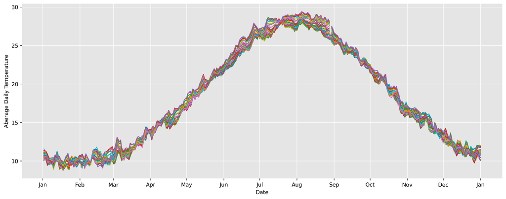

```python
fig, ax = plt.subplots(nrows=1, ncols=1, figsize=(16,6))
ax.set_axisbelow(True)
ax.set_ylabel('Aberage Daily Temperature')
ax.set_xlabel('Date')
ax.spines['top'].set_visible(False)
ax.spines['right'].set_visible(False)
ax.spines['bottom'].set_visible(False)
ax.spines['left'].set_visible(False)
ax.set_facecolor('#E5E5E5')
plt.grid(color='w')

# got this code snippet from StackOverflow. It maps the days of the year to the appropriate months

import datetime as dt
import matplotlib.dates as mdates
start = dt.datetime(2016,1,1)    #there has to be a year given, even if it isn't plotted
new_dates = [start + dt.timedelta(days=i) for i in range(366)]
x = new_dates
y = df_TEMP.index

xfmt = mdates.DateFormatter('%b')
months = mdates.MonthLocator()
ax.xaxis.set_major_locator(months)
ax.xaxis.set_major_formatter(xfmt)


# Now we plot our lines usings a loop to get the rows one by one
for _, year in df_TEMP_rolling.iterrows():
    plt.plot(year.index, year.values)
```

### Q4: Extreme Temperature Events

Another mesure used by climatologists is the number of extreme events. Extreme events are defined as those beyond 5% or 10% from the expected value. We will deal with extreme heat events going 10% above the baseline.

You will count the number of extreme temperature events per year, compared to the baseline of 1974-1999. You should should produce a graph like the one that follows. The vertical axis is the percentage of extreme heat events calculated over the number of observations for each year. The gray line in the middle is the average percentage of extreme tempearture events of the baseline. The colour blue is used for those years where the percentage is below the baseline; otherwise the colour is orange. What is your interpretation of the graph?

[figure not shown]

We calculate the baseline of the temperatures from 1974-1999.

```python
baseline = df_TEMP_PRCP[(df_TEMP_PRCP.index.year>=1974) & (df_TEMP_PRCP.index.year<=1999)].TAVG.mean()
```

```python
baseline
```

```
17.852632687447347
```

Here we get the days with temperatures above the 110% of the baseline and then we count them.

```python
df_extreme = df_TEMP_PRCP[df_TEMP_PRCP.TAVG > 1.1 * baseline]
```

```python
df_extreme_days = df_extreme.groupby(df_extreme.index.year).count()
```

```python
df_extreme_days['years'] = df_extreme_days.index
```

Calculate number of extreme days between 1974 and 1999.

```python
number_of_extreme_days_74_99 = df_extreme_days[(df_extreme_days.index>=1974) & (df_extreme_days.index<=1999)].TAVG.sum()
```

```python
# importing calendat to get leap years
import calendar
```

```python
df_extreme_days['number_of_days_in_year'] = df_extreme_days.years.apply(lambda x: 366 if calendar.isleap(x) else 365)
```

```python
df_extreme_days['percentage'] = df_extreme_days.TAVG / df_extreme_days.number_of_days_in_year
```

```python
number_of_baseline_days = df_extreme_days[(df_extreme_days.index>=1974) & (df_extreme_days.index<=1999)]['number_of_days_in_year'].sum()
```

Calculate baseline percentage.

```python
baseline_percentage = number_of_extreme_days_74_99 / number_of_baseline_days
```

```python
baseline_percentage
```

```
0.413647851727043
```

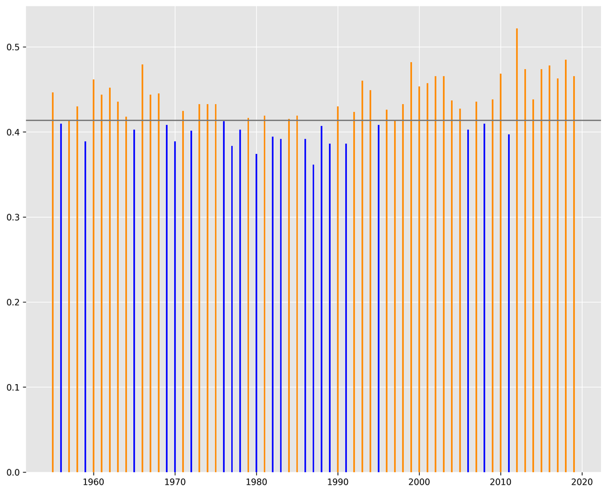

```python
fig, ax = plt.subplots(nrows=1, ncols=1, figsize=(12,10))
ax.set_axisbelow(True)
ax.spines['top'].set_visible(False)
ax.spines['right'].set_visible(False)
ax.spines['bottom'].set_visible(False)
ax.spines['left'].set_visible(False)
ax.set_facecolor('#E5E5E5')
plt.grid(color='w')
colors = ['#FF8C00' if i>baseline_percentage else "b" for i in df_extreme_days.percentage]
plt.bar(df_extreme_days.index, df_extreme_days.percentage, width=0.2,color=colors)
plt.axhline(y=baseline_percentage, color='#777777')
```

The interpretation of the graph is that in recent years extreme heat events are much more prevalent than in the past.

### Q5: Precipitation

Continuing the thread on extreme events, another consideration is rainfall. The weather may or may not be drying up. We are, however, interested in whether precipication becomes more intense over time.

To see that, you will count the overall rainfall over the year and the number of rainy days in each year. Then, by dividing the rainfall by the number of rainy days you will get an indication of whether we are getting rain in more concentrated bursts. You will then create a plot showing the ratio of rainfall over rainy days over the years. On the plot you will overlay the 10 years rolling average. The plot should be similar to the one below. What is your interpretation of the plot?

[figure not shown]

Firstly, we get the sum of the precipitation for each year.

```python
prcp_sum = df_TEMP_PRCP.groupby(df_TEMP_PRCP.index.year).sum()['PRCP']
```

Then we make a dataframe with only the days that had some rainfall and count how mnay those days were per year.

```python
df_PRCP = df_TEMP_PRCP[df_TEMP_PRCP.PRCP > 0]
```

```python
df_PRCP.groupby(df_PRCP.index.year).count()
```

| DATE | TAVG | TMIN | TMAX | PRCP |
| --- | --- | --- | --- | --- |
| 1955 | 68 | 68 | 68 | 68 |
| 1956 | 52 | 52 | 52 | 52 |
| 1957 | 72 | 72 | 73 | 73 |
| 1958 | 68 | 68 | 68 | 68 |
| 1959 | 62 | 62 | 62 | 62 |
| ... | ... | ... | ... | ... |
| 2015 | 41 | 41 | 41 | 41 |
| 2016 | 42 | 42 | 42 | 42 |
| 2017 | 48 | 48 | 48 | 48 |
| 2018 | 55 | 55 | 55 | 55 |
| 2019 | 58 | 58 | 58 | 58 |

65 rows × 4 columns

```python
prcp_num_days = df_TEMP_PRCP[df_TEMP_PRCP.PRCP > 0].groupby(df_TEMP_PRCP[df_TEMP_PRCP.PRCP > 0].index.year).count()['PRCP']
```

We divide the sum of the rainfall amount in mm of every year with the number that it rained in every year.

```python
prcp_burst = prcp_sum / prcp_num_days
```

```python
prcp_burst.index
```

```
Int64Index([1955, 1956, 1957, 1958, 1959, 1960, 1961, 1962, 1963, 1964, 1965,
            1966, 1967, 1968, 1969, 1970, 1971, 1972, 1973, 1974, 1975, 1976,
            1977, 1978, 1979, 1980, 1981, 1982, 1983, 1984, 1985, 1986, 1987,
            1988, 1989, 1990, 1991, 1992, 1993, 1994, 1995, 1996, 1997, 1998,
            1999, 2000, 2001, 2002, 2003, 2004, 2005, 2006, 2007, 2008, 2009,
            2010, 2011, 2012, 2013, 2014, 2015, 2016, 2017, 2018, 2019],
           dtype='int64', name='DATE')
```

We calculate the rolling average.

```python
prcp_rolling = prcp_burst.rolling(window=10, min_periods=1).mean()
```

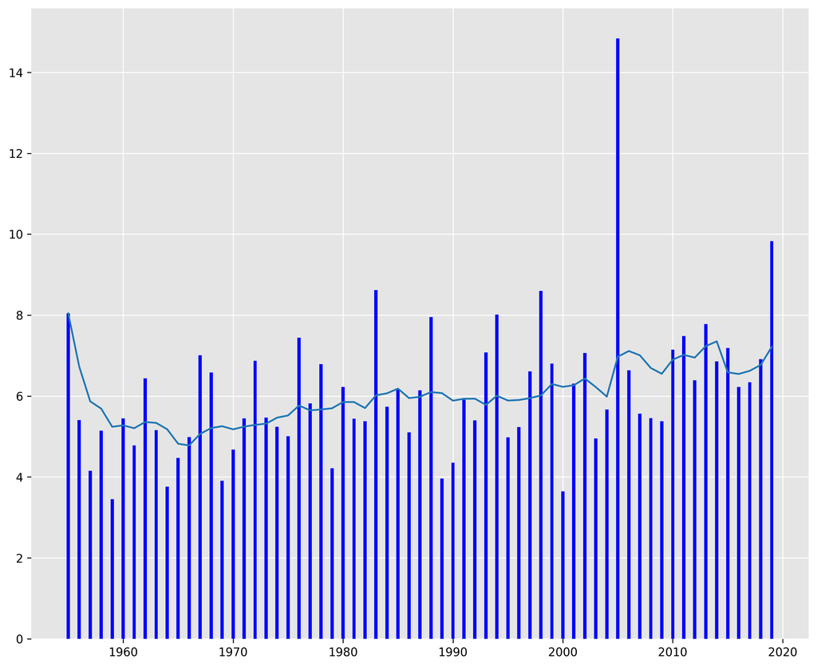

```python
fig, ax = plt.subplots(nrows=1, ncols=1, figsize=(12,10))
ax.set_axisbelow(True)
ax.spines['top'].set_visible(False)
ax.spines['right'].set_visible(False)
ax.spines['bottom'].set_visible(False)
ax.spines['left'].set_visible(False)
ax.set_facecolor('#E5E5E5')
plt.grid(color='w')
plt.bar(prcp_burst.index, prcp_burst,width=0.3, color='b')
plt.plot(prcp_rolling.index, prcp_rolling)
```

My interpretation of the graph is that there is some steady increase in the intensity of the rainfall as we go from the 60's to today.

###### Parting thoughts

I see that my graphs have a lot of differences to the given graphs. I believe this has to do with the hypothesis that I did early in the study that I can create many average temperatures by averaging min and max temperatures per day. Many of these temperatures created could be way off and play significant role in how the graphs are produced. Maybe it could be safe to leave them as NaN and just have some missing lines in the graphs as the ones depicted.

## Submission Instructions

You will submit a Jupyter notebook that will contain all your code and analysis. Ensure that the notebook will run correctly in a computer that is not your own. That means, among other things, that it does not contain absolute paths. Remember that a notebook is not a collection of code cells thrown together; it should contain as much text as necessary for a person to understand what you are doing.

## Honor Code

You understand that this is an individual assignment, and as such you must carry it out alone. You may seek help on the Internet, by Googling or searching in StackOverflow for general questions pertaining to the use of Python, libraries, and idioms. However, it is not right to ask direct questions that relate to the assignment and where people will actually solve your problem by answering them. You may discuss with your fellow students in order to better understand the questions, if they are not clear enough, but you should not ask them to share their answers with you, or to help you by giving specific advice.

← Previous